# Reproducible Research: Peer Assessment 1

Tom

Wednesday, June 03, 2015

# Introduction

It is now possible to collect a large amount of data about personal movement using activity monitoring devices such as a Fitbit, Nike Fuelband, or Jawbone Up. These type of devices are part of the “quantified self” movement !V a group of enthusiasts who take measurements about themselves regularly to improve their health, to find patterns in their behavior, or because they are tech geeks. But these data remain under-utilized both because the raw data are hard to obtain and there is a lack of statistical methods and software for processing and interpreting the data.

## Preprocessing data

```r
data <- read.csv("activity.csv")
```

## The mean total number of steps taken per day

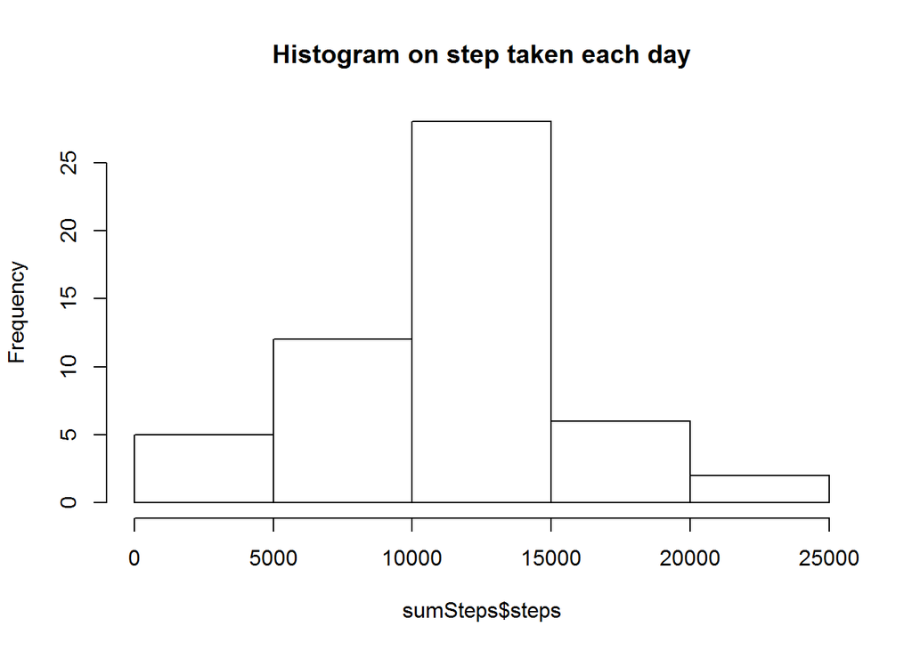

```r
sumSteps <- aggregate(data$steps ~ data$date, FUN=sum)
names(sumSteps) <- c("date", "steps")
hist(sumSteps$steps, main="Histogram on step taken each day")
```

The mean of the total number of steps taken per day

```r
mean(sumSteps$steps)
```

```
## [1] 10766.19
```

The median of the total number of steps taken per day

```r
median(sumSteps$steps)
```

```
## [1] 10765
```

## The average daily activity pattern

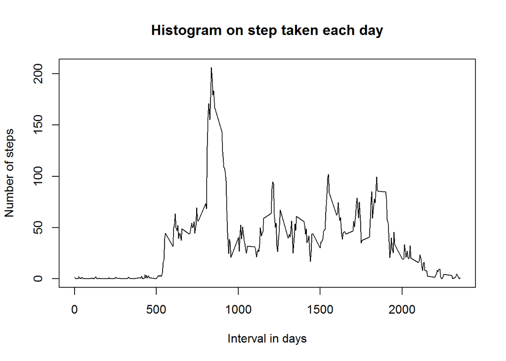

```r
avgSteps <- aggregate(data$steps ~ data$interval, FUN=mean)
names(avgSteps) <- c("interval", "steps")
plot(avgSteps$interval,avgSteps$steps , type="l", main="Histogram on step taken each day", xlab="Interval in days", ylab="Number of steps")
```

## Imputing missing value

The missing value is replaced by the mean for that 5-minute interval. A new histogram is plotted and mean and median is recalculated.

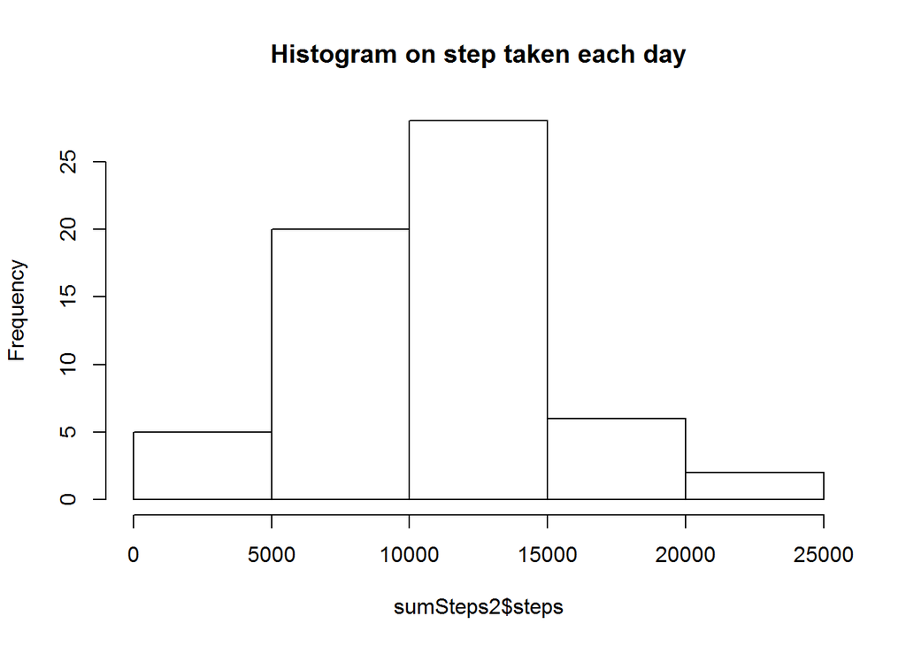

```r
imputData <- data
imputData$steps <- apply(data, 1, function(x){
  if(is.na(x[1]))
    avgSteps$steps[avgSteps$interval==x[3]][1]
  else
    x[1]
})
imputData$steps <- as.numeric(imputData$steps)
sumSteps2 <- aggregate(imputData$steps ~ imputData$date, FUN=sum)
names(sumSteps2) <- c("date", "steps")
hist(sumSteps2$steps, main="Histogram on step taken each day")
```

The mean of the total number of steps taken per day (Missing value)

```r
mean(sumSteps2$steps)
```

```
## [1] 10221.93
```

The median of the total number of steps taken per day

```r
median(sumSteps2$steps)
```

```
## [1] 10395
```

After imputing missing data using the estimates, the new mean and median is smaller from that of the original data set.

## The difference between weekday and weekend

```r
weekData <- data
Sys.setlocale("LC_ALL","English")
```

```
## [1] "LC_COLLATE=English_United States.1252;LC_CTYPE=English_United States.1252;LC_MONETARY=English_United States.1252;LC_NUMERIC=C;LC_TIME=English_United States.1252"
```

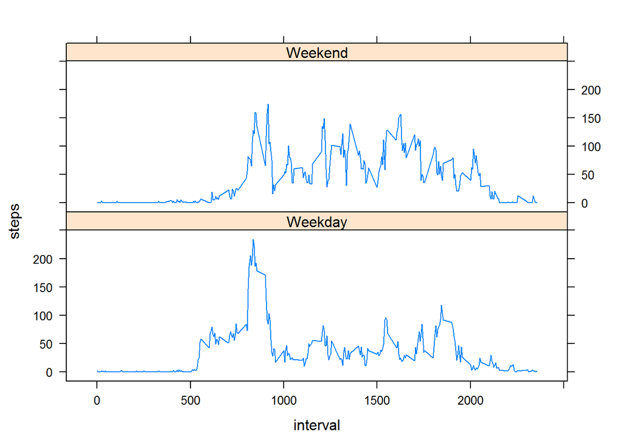

```r
weekData$wd <- apply(weekData, 1, function(x){
    t<-weekdays(as.Date(x[2]))
    if(t=="Sunday")
      "Weekend"
    else if(t=="Saturday")
      "Weekend"
    else
      "Weekday"
  }
)
weekAvgSteps <- aggregate(weekData$steps ~ weekData$interval+weekData$wd, FUN=mean)
names(weekAvgSteps) <- c("interval", "wd", "steps")
weekAvgSteps <- transform(weekAvgSteps, wd=factor(wd))
library (datasets)
library(lattice)
xyplot(steps ~ interval | wd, data=weekAvgSteps, type="l", layout=c(1,2))
```